# Lab-02 Part B: The Eight Step Process®

## Step 6: Implement Response Objectives

### Function

This is the phase where emergency responders **apply the best available strategies and tactics to ensure the most favorable outcome**.

If the incident is in the emergency phase, this is where we make the problem go away.

Common strategies to protect people and stabilize the problem include:

- Rescue.
- Public protective actions.
- Spill control.
- Leak control.
- Fire control.
- Clean-up and recovery operations.

These strategies are typically implemented by fire, rescue, and hazardous materials units, whereas law enforcement is usually responsible for all security and criminal-related issues.

In the post-emergency response phase, response personnel will likely focus on scene safety, clean-up, evidence preservation, and incident investigation.

Specific tasks will include:

- Initial site entry and monitoring to determine the extent of the hazards present.
- An evaluation of the scene to locate evidence that can be used to reconstruct the events leading up to the incident.
- Identification of the factors that contributed to the cause of the incident.
- Interviewing on-scene personnel and witnesses to verify the information obtained and opinions formed based on the available data.
- Documentation of preliminary results.

### Goal

**Ensure incident priorities (i.e., rescue, incident stabilization, environmental and property protection) are accomplished in a safe, timely, and effective manner.**

### Checklist

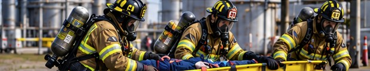

Firefighters wearing structural firefighting protective clothing and SCBA conducting a rescue operation.

**Rescue**

- Implement response objectives involving rescue.

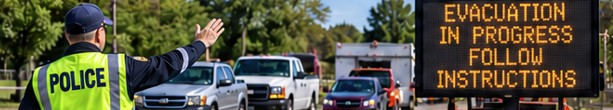

Police officer directing traffic and coordinating evacuation during a hazardous materials emergency.

**Public protective actions**

- Implement response objectives involving public protective actions.

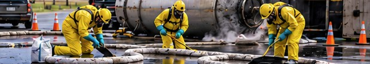

Hazardous materials responders using containment materials to control a chemical spill.

**Spill control**

- Implement response objectives involving spill control.

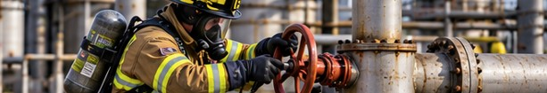

Firefighter wearing respiratory protection operating a valve to control a hazardous materials leak.

**Leak control**

- Implement response objectives involving leak control.

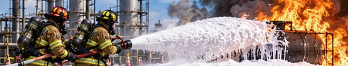

Firefighters applying firefighting foam to a burning industrial container.

**Fire control**

- Implement response objectives involving fire control.

[figure not shown]

Hazardous materials personnel conducting site cleanup, recovery, and incident documentation.

**Clean-up and recovery operations**

- Implement response objectives involving clean-up and recovery operations.

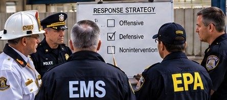

Incident response personnel evaluating tactical options and firefighting operations at a hazardous materials incident.

**Select and implement response tactics**

Implement response objectives.

Remember that **offensive tactics increase the risks to emergency responders**. Evaluate the risks of offensive control tactics before sending emergency response crews into the hazard area.

- **Offensive tactics:** Require responders to control or mitigate the emergency from within the area of high risk.
- **Defensive tactics:** Permit responders to control or mitigate the emergency from outside the area of highest risk.
- **Nonintervention tactics:** Implement a passive response posture until additional personnel or equipment arrive, or allow the fire to burn itself out.

**NoteTactical Flexibility**

Rapidly changing incident conditions may require using multiple tactics simultaneously or switching from one tactic to another.

**Defensive tactics are always desirable over offensive tactics if they can accomplish the same objectives.**

### Entry Operations and Personnel Safety

- Ensure backup personnel are properly equipped with the appropriate level of personal protective clothing and are in place before initiating operations.
- Ensure any detection or monitoring equipment is operational and properly calibrated.
- Ensure entry teams have been briefed before they are allowed to enter the hot zone.

For hazmat emergencies, entry team briefings should include:

- Removal of all watches, jewelry, and personal valuables (e.g., wallets, cell phones).
- Objectives of the entry operation.
- Known hazards within the area, including physical hazards (e.g., downed power lines, stairwells, open pits).
- Safety procedures, including medical, radio communications, SCBA, and PPE checks.
- Emergency procedures, including placement of backup teams, escape signals, and escape corridors.
- Decon area location, set-up, and procedures.

Conduct regular monitoring of the hazard area to determine if conditions are changing.

**NoteCaution**

**Decon should be set up before initiating entry operations.**

For situations where civilians are down and chemical exposures are suspected, establish emergency decon as soon as possible.

**ImportantOperational Considerations**

- **Evaluate nonintervention:** What will happen if I do nothing? Remember, this is the baseline for hazmat decision making and should be the scenario against which all strategies and tactics are compared.
- **Positive-pressure ventilation:** Positive-pressure ventilation can be used to:
  - Significantly reduce chemical vapor levels in a building.
  - Increase the safety of emergency responders who must enter a structure to perform rescue operations.

  Keep exposure hazards downwind, if applicable.
- **Illicit laboratory operations:** Never touch or handle anything in an illicit lab operation until the area has been cleared by bomb squad personnel. This includes surveying and identifying the area for possible booby traps.
- **Energetic materials:** There is a very fine line between explosives, oxidizers, and organic peroxides. All can release large amounts of energy.
- **Maintain contingency plans:** Surprises are nice on your birthday but not on the emergency scene. **Always have a Plan B in case Plan A doesn’t work!**

## Step 7: Decon and Clean-Up Operations

### Function

**Decontamination is the process of making personnel, equipment, and supplies safe by reducing or eliminating harmful substances (i.e., contaminants)** in contaminated areas (i.e., hot zone or inner perimeter).

Decon is commonly viewed in terms of cleaning personnel and equipment after entry operations. However, there are situations where, due to the type of materials involved, decon of clothing and equipment may not be possible and items may require disposal.

All personnel trained to the first responder operations level should be able to perform or deliver an emergency decon capability.

At most working hazmat incidents, hazardous materials response teams (HMRTs) or fire and rescue units working under the direction of a hazmat technician will provide technical decon services.

Questions about disposal methods and procedures should be directed to environmental officials and technical specialists, based on applicable federal, state, and local regulations.

### Goal

**Ensure the safety of both emergency responders and the public** by reducing:

1. The level of contamination on scene.
2. The potential for secondary contamination beyond the incident scene.

### Checklist

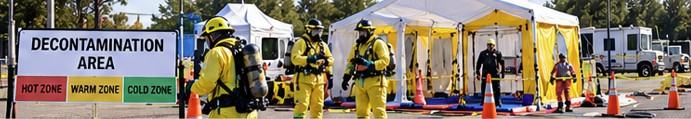

Hazardous materials responders coordinating technical decontamination operations with tactical response personnel.

**Coordinate decontamination with tactical operations**

- Ensure technical decon operations are coordinated with tactical operations.
- Properly locate the decon area within the warm zone, preferably upslope and upwind of the incident location.

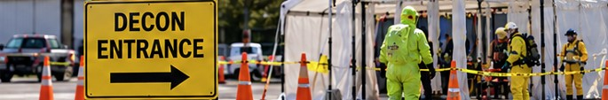

Clearly marked hazardous materials decontamination area with designated entry and exit routes.

**Clearly mark and identify the decon area**

- Clearly mark and identify the decon area.

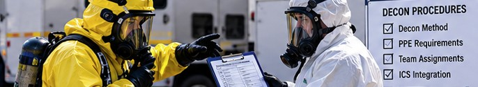

Hazardous materials personnel selecting decontamination methods, protective equipment, and coordinating with incident command.

**Determine decon method, PPE, and integrate with ICS**

- Determine and communicate the proper decon method and type of personal protective clothing to be worn by the decon team, as appropriate.
- Integrate all decon operations with the ICS organization.

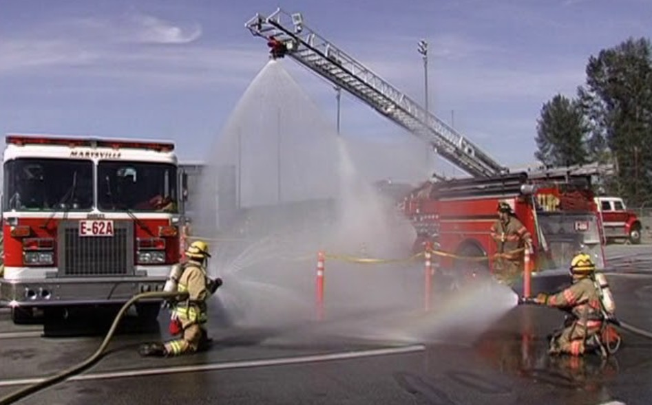

Emergency responders establishing a mass decontamination corridor for potentially contaminated civilians.

**Establish mass decontamination operations**

Incidents involving large numbers of contaminated or potentially contaminated people require the establishment of a mass decon operation.

Basic principles of mass casualty decon include:

- Expect a five-to-one ratio of unaffected to affected casualties. For every victim who is physically contaminated, five others may be exposed or think they are contaminated.
- Decontaminate as soon as possible. You may need to corral contaminated people until a mass decon corridor is established.

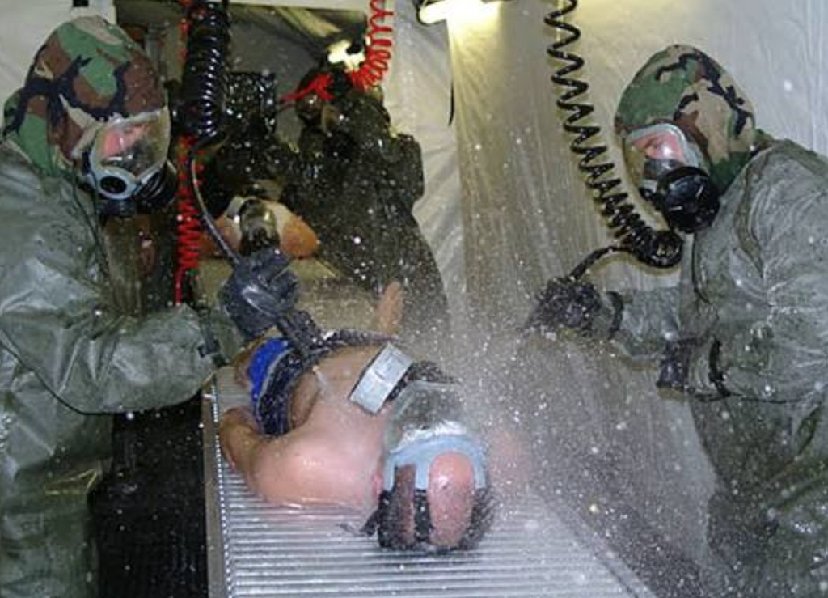

Emergency responders conducting hazardous materials decontamination procedures using water flushing.

**Implement effective decontamination procedures**

- Disrobing is decon. Undress from top to bottom—more is better.
- Water flushing for 3 minutes is usually the best mass decon method.
- After a known exposure to a hazmat, responders must decon as soon as possible to avoid serious effects.

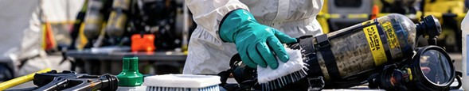

Hazardous materials response personnel managing contaminated equipment and hazardous waste disposal.

**Clean up or dispose of contaminated supplies and equipment**

- Ensure proper decon of all personnel before they leave the scene. For example, flammable gases and some toxic and corrosive gases can saturate protective clothing and be carried into safe areas.
- Establish a plan to clean up or dispose of contaminated supplies and equipment before cleaning up the site of a release.
- Federal and state laws require proper disposal of hazardous waste.

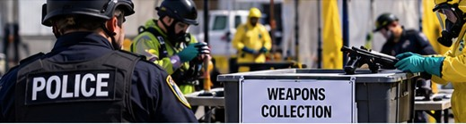

Emergency response personnel addressing decontamination planning, medical transport, and law enforcement security considerations.

**Address special considerations**

- Establish an emergency decon capability as part of the incident action plan for hazmat incidents.
- Ensure personnel and contaminated victims are decontaminated before leaving the scene.
- Address law enforcement and security concerns during decon operations.

**ImportantResponder Tips**

- **Emergency decon planning:** Establishing an emergency decon capability should be part of the incident action plan for any hazmat incident (e.g., illicit labs, special weapons and tactics [SWAT] tactical operations).
- **Mass decon challenges:** Decon involving large numbers of people will be a challenge and will make for a long day. Remember the basics: separate the people from the problem and keep them contained until mass decon is established. It won’t be easy, and it can get ugly.
- **Permeation:** Permeation can occur with any porous material (e.g., shoes, belts, fire hose, holsters, gun stocks), not just PPE.
- **Sodium hypochlorite:** Sodium hypochlorite (i.e., bleach) may be used as a decon agent for equipment when dealing with chemical and biological materials. Be aware that bleach will degrade some materials (e.g., Kevlar™) and will shorten the life of the material.
- **Skin exposure:** Degradation chemicals, such as bleach, should never be applied directly to the skin.
- **Medical transport:** Never transport contaminated victims from the scene to any medical facility without conducting field decon. At best, healthcare workers will be mad at you. At worst, you will endanger other people and completely shut down the emergency room of the hospital.
- **Law enforcement considerations:** Law enforcement operations at incidents where hazmats are involved can create some unique challenges:
  - Be aware that suspects may be among civilians during mass decon operations.
  - Make sure all weapons are properly handled and made safe by establishing a weapons safety officer as part of decon.
  - Ensure security procedures are in place when conducting decon of contaminated prisoners.

## Step 8: Terminate the Incident

### Function

This is the **termination of emergency response activities and the beginning of post-emergency response operations (PERO)**.

This includes:

- Investigation.
- Restoration.
- Recovery activities.

It also includes the transfer of command to the agency that will be responsible for coordinating all post-emergency activities.

### Goal

**Ensure overall command is transferred to the proper agency** when:

1. The emergency is terminated.
2. All post-incident administrative activities are completed per local policies and procedures.

### Checklist

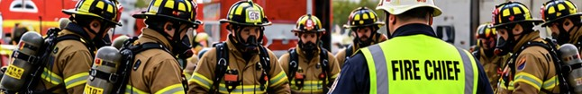

Fire chief conducting personnel accountability with firefighters and hazardous materials responders following emergency operations.

**Account for all personnel**

- Account for all personnel before securing emergency operations.

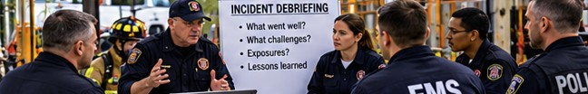

Emergency responders participating in a post-incident debriefing to discuss operations and document potential exposures.

**Conduct incident debriefings**

- Conduct incident debriefing sessions for on-scene response personnel.
- Provide background information needed to ensure the documentation of any exposures.

[figure not shown]

Incident commander formally transferring responsibility to an environmental agency representative for post-emergency operations.

**Transfer command**

- Ensure command is formally transferred from the lead response agency to the lead agency for all post-emergency response operations.

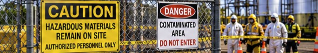

Hazardous materials warning signs identifying remaining contamination and restricted access at an incident scene.

**Communicate remaining hazards**

- Ensure public safety units are aware of any hazards remaining at the incident scene if emergency responders must return to the scene.

[figure not shown]

Emergency response personnel documenting operational, medical, regulatory, equipment, and contact information.

**Document incident operations**

Ensure the following elements are documented:

- All operational, regulatory, and medical phases of the emergency.
- All equipment and supplies used during the incident.
- The contact information (e.g., names, phone numbers, email addresses) of all key players. This includes contractors, public officials, and members of the media.

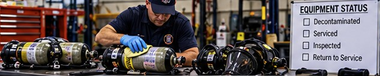

Fire department personnel inspecting and servicing emergency response equipment before returning it to service.

**Restore emergency equipment**

Ensure all emergency equipment is:

- Decontaminated.
- Reserviced.
- Inspected.
- Placed back in service.

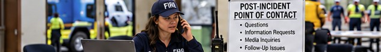

Fire department representative coordinating post-incident questions, information requests, and follow-up activities.

**Provide a post-incident point of contact**

- Provide a point of contact for all post-incident questions and issues.

[figure not shown]

Fire, police, EMS, and environmental agency representatives reviewing lessons learned during a formal incident critique.

**Conduct an incident critique**

- Conduct a critique of all major and significant incidents based on local protocols.

**ImportantResponder Tips: Learning from Incident Critiques**

- **Avoid assigning blame:** Although organizations tend to develop their own critique styles and processes, never use a critique to assign blame. Public meetings are the worst time to discipline personnel.
- **Focus on operational improvement:** Organizations must balance the potential negatives against the benefits of the critique process. The purpose of critiques is to improve your operations.
- **Three common approaches to incident critiques:**
  1. We lie to each other about what a great job we just did.
  2. We beat up each other for making mistakes.
  3. We focus on the lessons learned and the changes/improvements we must make to our response system.

**The objective is to identify lessons learned and improve future emergency response operations.**

## Application Example

### Incident Scenario: Suspected Illicit Drug Laboratory

You are a regional hazmat officer who has been requested to respond to an incident involving a suspected illicit drug laboratory.

Both fire service and law enforcement personnel are already on scene, and a suspected lab operator is now under arrest.

The suspected laboratory is located on the third floor of a four-story multifamily (i.e., garden apartment) building.

At this time, no entry operations have taken place, and emergency responders are in the process of developing their incident action plan (IAP).

As the hazmat officer, both fire and law enforcement leadership are looking for recommendations on how to proceed.

### 1. What are your incident objectives?

Your incident objectives might include:

- Ensuring the safety of responders and the public.
- Mitigating the illicit laboratory problem and its potential extension to other apartments and throughout the apartment building.
- Coordinating support to law enforcement and environmental agencies in investigating and mitigating the illicit laboratory problem.
- Coordinating evacuation and shelter operations.
- Coordinating information and intelligence gathering to all key stakeholders.

### 2. What are your incident priorities?

Your incident priorities might include:

- Life safety.
- Incident stabilization.
- Property and environmental protection.
- Critical infrastructure disruption.

### 3. What are your tactical priorities?

Your tactical priorities might include:

- Assessing the specific nature of the problem, including the type of illicit laboratory and the hazardous materials and types of containers present.
- Assessing the presence of potential booby traps, including weapons, chemicals, and explosives.
- Containing the hazmat problem in the involved apartment, including control of utilities and building systems, to minimize migration to other unaffected areas.
- Evacuating the occupants and establishing shelter operations, as necessary.

### 4. Identify any additional resources or specialized units that might be required as part of entry and control operations.

Additional resources or specialized units that might be required include:

- Emergency medical services (EMS) units to support both responders and civilian personnel.
- Bomb technician or bomb squad unit.
- Environmental crimes unit and/or environmental protection agency (local, state, or federal).
- Environmental clean-up contractor.
- Local emergency management agency representatives to coordinate evacuation and sheltering operations.

## Wrap-Up

### Summary

Emergency response operations at incidents involving hazardous materials must always be based on a **structured and standardized system of response protocols and procedures**.

No matter the nature of the incident, the response, or the personnel involved, standardized procedures:

1. Bring consistency to tactical operations.
2. Improve the delivery of a risk-based operational response capability.

If the situation may involve hazardous materials or weapons of mass destruction (WMD) agents, standardized tactical response procedures will help minimize the risk of exposure to all responders.

The **Eight Step Process®** is a tool used for the tactical management of hazardous materials emergencies. It serves as an example of a structured system that can be used by response personnel at incidents.

While the level of equipment, training, and personnel may vary among organizations, there are basic functions and tasks that must be consistently evaluated and applied at hazardous materials incidents.

The Eight Step Process® provides the framework to translate planning and preparedness into the delivery of an effective system for responding to incidents where hazardous materials and WMDs may be involved.

### The Eight Functions of the Eight Step Process®

The eight functions within the Eight Step Process® are:

1. **Site management and control**
2. **Identify the problem**
3. **Hazard assessment and risk evaluation**
4. **Select personal protective clothing and equipment**
5. **Information management and resource coordination**
6. **Implement response objectives**
7. **Decon and clean-up operations**
8. **Terminate the incident**

**© 2026 Yoni Rodriguez. All rights reserved.**

*SHM 377 — Hazardous Materials Management*  
Central Washington University

*Instructional organization, original illustrations, and supplemental educational materials developed by Yoni Rodriguez.*

*Adapted instructional content and the Eight Step Process® are attributed to Hazardous Materials: Managing the Incident, Jones & Bartlett Learning. Original publisher rights remain with their respective owners.*